# Two-Sample Problem with OpenBUGS: Comparing means

Dhafer Malouche

## Introduction

We willl deal in this note with a two-sample model in which two independent samples are assumed to be normal with the same population variance and in which we seek an interval estimate for the difference between the population means.

We use flat prior distributions, so the numerical results should be nearly the same as we would get from a frequentist two-sample t procedure.

## Statistical Model

Suppose that we had collected the same quantitative data on two different groups:
$$y_1^1,\ldots,y_{n_1}^1$$
and
$$y_1^2,\ldots,y_{n_2}^2$$
Since our aim is to compare the average of both groups by assuming that both of them are sampled from an univariate Gaussian distribution with means respectively $\mu^1$ and $\mu^2$ and with a same precision matrix $\tau$.

Since we don’t have any solid prior information on the parameters we will then choose flat priors on the parameters.

Hence our Bayesian Statistical Model is defined as follows

$$y_1^1,\ldots,y_{n_1}^1\sim\mathcal{N}(\mu^1,\tau)$$
and
$$y_1^2,\ldots,y_{n_2}^2\sim\mathcal{N}(\mu^2,\tau)$$
where
$$\pi(\mu^1,\mu^2)\propto \mathbb{1}_{\mathbb{R}^2}(\mu^1,\mu^2)\,\mathbb{1}_{\mathbb{R}^*_+}(\tau)$$

## BUGS Code

```r
model{
for(i in 1:n1) {
y1[i] ~ dnorm(mu1, tau)
}
for(j in 1:n2) {
y2[j] ~ dnorm(mu2, tau)
}
mu1 ~ dnorm(0.0, 1.0E-6)
mu2 ~ dnorm(0.0, 1.0E-6)
tau ~ dgamma(0.01, 0.001)
sigma <- 1/sqrt(tau)
delta <- mu1 - mu2
}
```

## Data

```r
dt=list(y1 = c(462, 397, 523, 481, 494, 430, 516, 472,
521, 397, 441, 474, 468, 503, 492, 383,
432, 569, 444, 534, 437, 553, 434, 435), y2 = c(237, 260, 340, 322, 255, 273, 252, 316, 276, 339, 304, 268, 291, 355, 292, 225, 381, 334, 256, 325, 413, 307, 308, 312), n1=24, n2=24)
```

## Frequentist Approach

`t.test` is the `R` command that can be used to perfom a comparaison mean test with equal variance.

```r
> t.test(dt$y1,dt$y2,alternative = "two.sided",var.equal=TRUE)
```

```
##
##  Two Sample t-test
##
## data:  dt$y1 and dt$y2
## t = 12.227, df = 46, p-value = 4.685e-16
## alternative hypothesis: true difference in means is not equal to 0
## 95 percent confidence interval:
##  141.0042 196.5791
## sample estimates:
## mean of x mean of y
##  470.5000  301.7083
```

## Bayesian Approach: Using `R2OpenBUGS`

- We had first to write the BUGS code of the model in a separate file

```r
sink('exCompMean.txt')
cat("
model{
for(i in 1:n1) {
y1[i] ~ dnorm(mu1, tau)
}
for(j in 1:n2) {
y2[j] ~ dnorm(mu2, tau)
}
mu1 ~ dnorm(0.0, 1.0E-6)
mu2 ~ dnorm(0.0, 1.0E-6)
tau ~ dgamma(0.01, 0.001)
sigma <- 1/sqrt(tau)
delta <- mu1 - mu2
}
",fill=T)
sink()
```

- Let us write an `R` function that can be used to initialize the Markov Chain

```r
> inits=function(){
+   inits=list(mu1=rnorm(1),mu2=runif(1),tau=rexp(1,rate = 1))
+ }
```

- We should specify which parameters have to be estimated:

```r
> params <- c('mu1','mu2','delta')
```

- Now, we can run the Markov Chain

```r
> library(R2OpenBUGS)
> filename<-'exCompMean.txt'
> outCmean <-bugs(dt,inits,params,filename,codaPkg=F,
+                 n.thin =1, n.iter=1000,debug=F,
+                 n.chains = 2,working.directory=getwd())
> outCmean
```

[output not shown]

## Convergence Diagnostic Analysis

### Model Checking: The deviance of the model

```r
> dim(outCmean$sims.array)
```

```
## [1] 1000    2    4
```

1000 is the sample size of the MC, 2 is the number of MC and 4 is the number of parameters: `mu1`, `mu2`, `delta` and the deviance of the model:

- `DIC` (Deviance Information Criteria) and `pD` parameters: `pD` provides an estimation of the effective number of parameters in the model, and `DIC` measures the goodness-of-fit of the model to the data. It provides an estimate of expected predictive error (lower deviance is better).

```r
> outCmean$pD
```

```
## [1] 3.016
```

```r
> outCmean$DIC
```

```
## [1] 511.5
```

### CODA

- Tracing the history of each parameter. For example $\mu^1$:

```r
> library(coda)
> mu1=mcmc(outCmean$sims.array[,,1])
> dim(mu1)
```

```
## [1] 1000    2
```

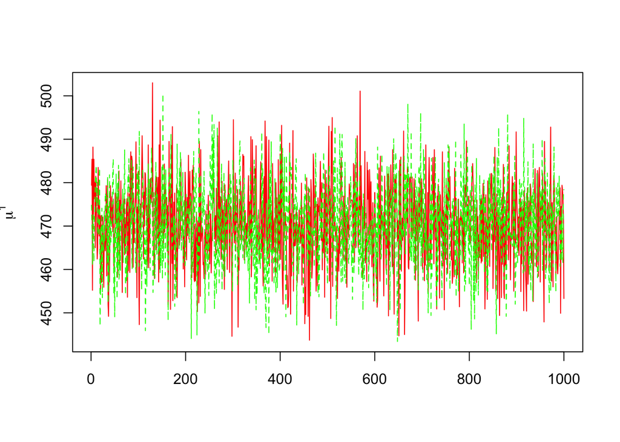

```r
> matplot(mu1,col=c("red","green"),type="l",ylab=expression(mu^1))
```

- Autocorrelation graph

```r
> autocorr.diag(mu1)
```

```
##               [,1]         [,2]
## Lag 0   1.00000000  1.000000000
## Lag 1   0.01556605 -0.005929771
## Lag 5   0.02089058 -0.027590187
## Lag 10  0.04427924 -0.018452354
## Lag 50 -0.08030862  0.002033798
```

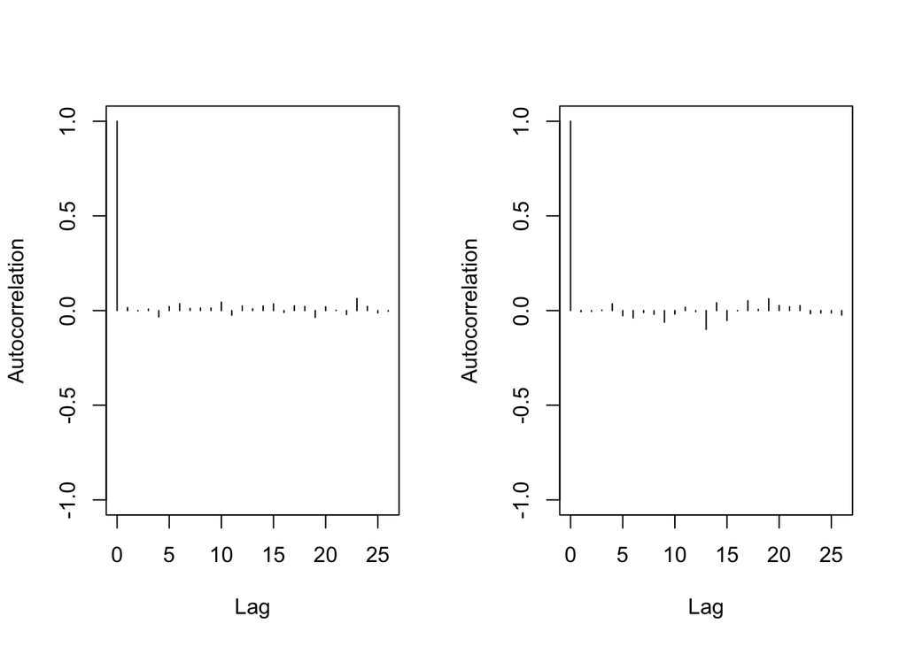

```r
> autocorr.plot(mu1)
```

- We also compute a coefficient call $\widehat{R}$ called The *potential scale reduction factor*. It is calculated for each estimated parametr, together with upper and lower confidence limits. Approximate convergence is diagnosed when the upper limit is close to 1. For multivariate chains, a multivariate value is calculated that bounds above the potential scale reduction factor for any linear combination of the (possibly transformed) variables.

$\widehat{R}$ is greater than 1 and it declines to 1 when the number of iteration inscreases.

```r
> gelman.diag(list(mu1[,1],mu1[,2]))
```

```
## Potential scale reduction factors:
##
##      Point est. Upper C.I.
## [1,]          1          1
```

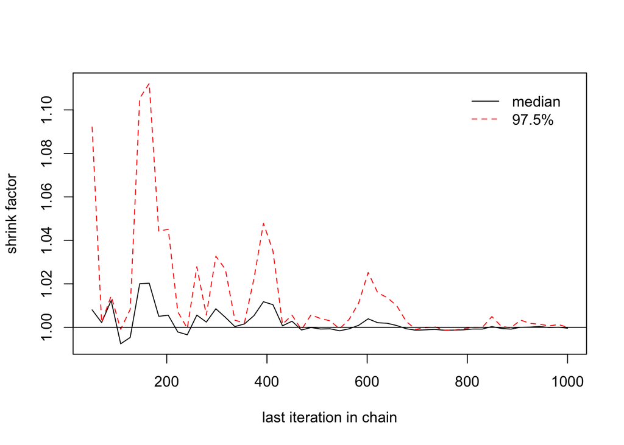

```r
gelman.plot(list(mu1[,1],mu1[,2]))
```

- Indeed $\widehat{R}$ is expressed as follows:

$$\widehat{R}=\sqrt{\displaystyle\frac{\mbox{var}(\psi\mid y)}{W}}$$
Where

$\psi=\left(\psi\right)_{1\leq i\leq n,\; 1\leq j\leq m}$, $n$ is the size of each Markov Chain, $m$ is the number of Chains and $\psi$ represents the estimated parameter.

$W$ is the *within* variance :
$$W=\displaystyle\frac{1}{m}\sum_{j=1}^m s_j^2$$
where
$$s^2_j=\displaystyle\frac{1}{n-1}\sum_{i=1}^n (\psi_{ij}-\overline{\psi}_{+ j})^2$$

$\mbox{var}(\psi\mid y)$ is an average between the within and the between variances:
$$\mbox{var}(\psi\mid y)=\displaystyle\frac{n-1}{n} W+\displaystyle\frac{B}{n}$$
and where
$$B=\displaystyle\frac{n}{m-1}\sum_{j=1}^m(\overline{\psi}_{+ j}-\overline{\psi}_{++})^2$$

Here $\overline{\psi}_{++}$ and $\overline{\psi}_{+ j}$ are averages computed on $\psi$:
$$\overline{\psi}_{+ j}=\displaystyle\frac{1}{n}\sum_{i=1}^n\psi_{ij}$$
and
$$\overline{\psi}_{++}=\displaystyle\frac{1}{m}\sum_{j=1}^m \overline{\psi}_{+ j}$$

The test statistic is a standard Z-score: the difference between the two sample means divided by its estimated standard error. The standard error is estimated from the spectral density at zero and so takes into account any autocorrelation.

```r
> geweke.diag(mu1, frac1=0.1, frac2=0.5)
```

```
##
## Fraction in 1st window = 0.1
## Fraction in 2nd window = 0.5
##
##    var1    var2
## 0.04932 0.19942
```

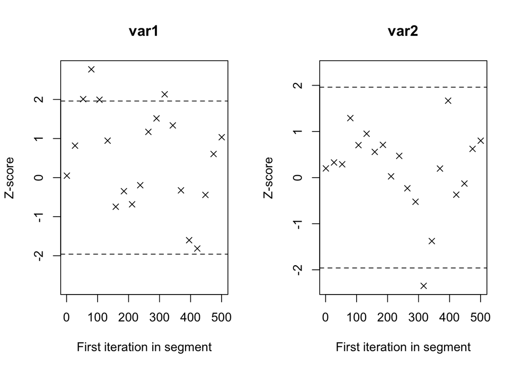

```r
> geweke.plot(mu1, frac1=0.1, frac2=0.5)
```